# {decorr} Graph and Spatial Analysis of Iconography for Archaeology

Thomas Huet

# Introduction

`decorr` package is used to study iconography with spatial and network analysis indexes. The `decorr` package has been grounded on the seminal work of C. Alexander and its first IT implementation (see, [Huet 2017](https://www.researchgate.net/publication/343514122_Geometric_graphs_to_study_ceramic_decoration))

# Install

Install the `decorr` package from GitHub and load it

```r
# devtools::install_github("zoometh/iconr")
library(decorr)
```

## Contents

### Functions

```r
cat(ls("package:decorr"),sep="\n")
```

```
#> labels_shadow
#> list_dec
#> list_eds_compar
#> list_nds_compar
#> plot_dec_grph
#> plot_eds_compar
#> plot_nds_compar
#> read_eds
#> read_nds
#> same_eds
#> same_nds
#> side_plot_eds
#> side_plot_nds
```

### External data

```r
doss <- system.file("extdata", package = "decorr")
cat(list.files(doss),sep="\n")
```

```
#> Brozas.Brozas.jpg
#> Cerro_Muriano.Cerro_Muriano_1.jpg
#> edges.csv
#> edges.dbf
#> edges.shp
#> edges.shx
#> edges.tsv
#> imgs.csv
#> imgs.tsv
#> nodes.csv
#> nodes.dbf
#> nodes.shp
#> nodes.shx
#> nodes.tsv
#> Torrejon_Rubio.Torrejon_Rubio_1.jpg
#> Zarza_de_Montanchez.Zarza_de_Montanchez.jpg
```

… you change change `doss` to the path of your working directory

#### Drawings/Images

Load an image with the `magick` package

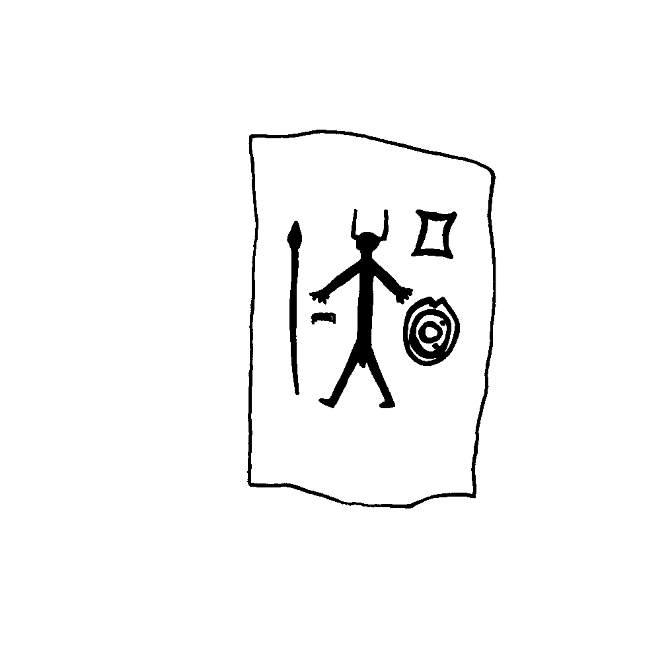

```r
drawing <- magick::image_read(system.file("extdata",
                                          "Cerro_Muriano.Cerro_Muriano_1.jpg",
                                          package = "decorr"))
plot(drawing)
```

#### Graph data

##### Nodes

a dataframe or a shapefile of the nodes

```r
setwd(system.file("extdata", package = "decorr"))
nds.df <- read_nds(site = "Cerro Muriano", decor = "Cerro Muriano 1")
knitr::kable(nds.df)
```

| site | decor | id | type | x | y |
| --- | --- | --- | --- | --- | --- |
| Cerro Muriano | Cerro Muriano 1 | 1 | personnage | 349.8148 | -298.3244 |
| Cerro Muriano | Cerro Muriano 1 | 2 | casque | 349.8148 | -243.9851 |
| Cerro Muriano | Cerro Muriano 1 | 3 | lance | 238.4637 | -298.3244 |
| Cerro Muriano | Cerro Muriano 1 | 4 | bouclier | 446.0222 | -381.1697 |
| Cerro Muriano | Cerro Muriano 1 | 5 | peigne | 283.0041 | -358.0086 |
| Cerro Muriano | Cerro Muriano 1 | 7 | sexe_masculin | 342.6884 | -427.4917 |
| Cerro Muriano | Cerro Muriano 1 | 8 | lingot_pdb | 451.1489 | -237.4782 |

- column names
  - `site`: decoration site
  - `decor`: decoration name
  - `id`: id of the edge (a unique number)
  - `type`: type of the node
  - `x,y`: coordinates of node

##### Edges

```r
setwd(system.file("extdata", package = "decorr"))
eds.df <- read_nds(site = "Cerro Muriano", decor = "Cerro Muriano 1")
knitr::kable(eds.df)
```

[output not shown]

## Examples

### Plot decoration graph

Plot “Cerro Muriano 1” nodes and edges for the field “type”

```r
setwd(system.file("extdata", package = "decorr"))
nds.df <- read_nds(site = "Cerro Muriano",decor = "Cerro Muriano 1")
eds.df <- read_eds(site = "Cerro Muriano",decor = "Cerro Muriano 1")
img.graph <- plot_dec_grph(nds.df = nds.df,
                           eds.df = eds.df,
                           site = "Cerro Muriano",
                           decor = "Cerro Muriano 1",
                           lbl.txt = "type",
                           shw = c("nodes","edges"))
```

```
#> [1] "nodes" "edges"
```

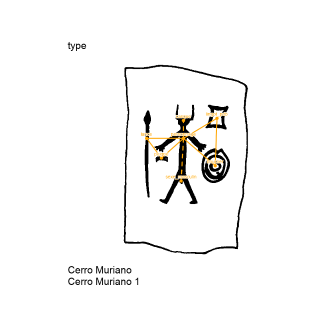

```r
plot(img.graph)
```

The output `img.graph` is a magick-image

```r
class(img.graph)
```

```
#> [1] "magick-image"
```

Replot the graph with “id” field instead of “type” field

```r
setwd(system.file("extdata", package = "decorr"))
nds.df <- read_nds(site = "Cerro Muriano",decor = "Cerro Muriano 1")
eds.df <- read_eds(site = "Cerro Muriano",decor = "Cerro Muriano 1")
img.graph <- plot_dec_grph(nds.df = nds.df,
                           eds.df = eds.df,
                           site = "Cerro Muriano",
                           decor = "Cerro Muriano 1",
                           lbl.txt = "id",
                           shw = c("nodes","edges"))
```

```
#> [1] "nodes" "edges"
```

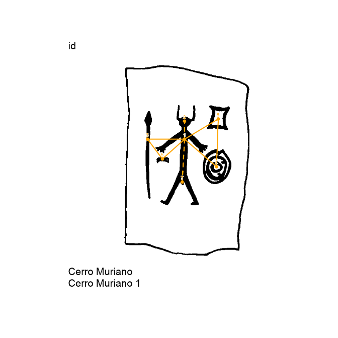

```r
plot(img.graph)
```

Replot the same graph with bigger and orange labels

```r
setwd(system.file("extdata", package = "decorr"))
nds.df <- read_nds(site = "Cerro Muriano",decor = "Cerro Muriano 1")
eds.df <- read_eds(site = "Cerro Muriano",decor = "Cerro Muriano 1")
img.graph <- plot_dec_grph(nds.df = nds.df,
                           eds.df = eds.df,
                           site = "Cerro Muriano",
                           decor = "Cerro Muriano 1",
                           lbl.txt = "id",
                           lbl.color = "orange",
                           lbl.size=2,
                           shw = c("nodes","edges"))
```

```
#> [1] "nodes" "edges"
```

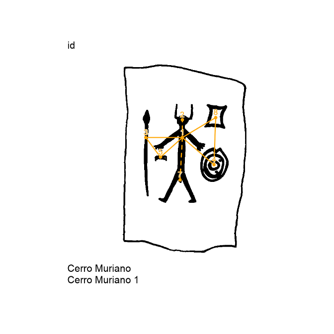

```r
plot(img.graph)
```

### Compare decoration graphs

#### Nodes

Count the common nodes between two decorations

```r
# set wd to data folder
setwd(system.file("extdata", package = "decorr"))
# read imgs, nodes and edges dataframes
imgs <- read.table(system.file("extdata", "imgs.tsv", package = "decorr"),
                   sep="\t",stringsAsFactors = FALSE)
nodes <- read.table(system.file("extdata", "nodes.tsv", package = "decorr"),
                    sep="\t",stringsAsFactors = FALSE)
edges <- read.table(system.file("extdata", "edges.tsv", package = "decorr"),
                    sep="\t",stringsAsFactors = FALSE)
lgrph <- list_dec(imgs,nodes,edges,"type") # call function
df.same_nodes <- same_nds(lgrph,"type")
knitr::kable(df.same_nodes,row.names = T)
```

|  | 1 | 2 | 3 | 4 |
| --- | --- | --- | --- | --- |
| 1 | 0 | 2 | 3 | 4 |
| 2 | 2 | 0 | 5 | 7 |
| 3 | 3 | 5 | 0 | 4 |
| 4 | 4 | 7 | 4 | 0 |

Here, the decorations `2` and `3` have five (5) common nodes. To show them, use the `plot_nds_compar(listg,graph2)` function

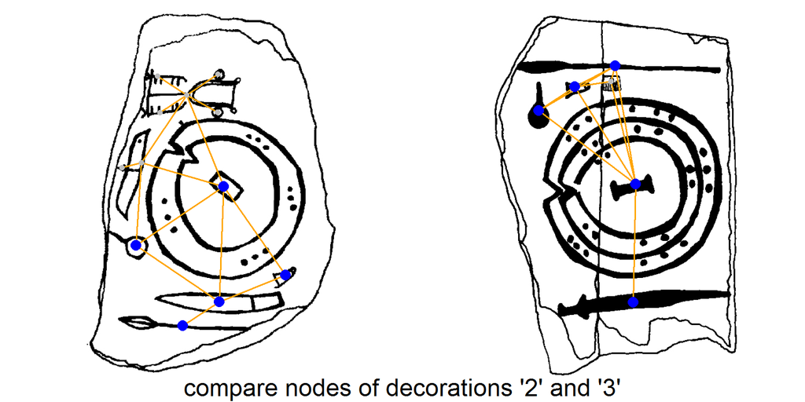

```r
# set wd to data folder
setwd(system.file("extdata", package = "decorr"))
# out.img path is only useful to open the output image
dec.to.compare <- c(2,3)
out.img <- paste0(getwd(),"/compar_nds_",dec.to.compare[1],"_",dec.to.compare[2],".png")
# read data
imgs <- read.table(system.file("extdata", "imgs.tsv", package = "decorr"),
                   sep="\t",stringsAsFactors = FALSE)
nodes <- read.table(system.file("extdata", "nodes.tsv", package = "decorr"),
                    sep="\t",stringsAsFactors = FALSE)
edges <- read.table(system.file("extdata", "edges.tsv", package = "decorr"),
                    sep="\t",stringsAsFactors = FALSE)
lgrph <- list_dec(imgs,nodes,edges,var="type")
g.compar <- list_nds_compar(lgrph,var="type")
plot_nds_compar(g.compar,dec.to.compare)
# open image
knitr::include_graphics(out.img)
```

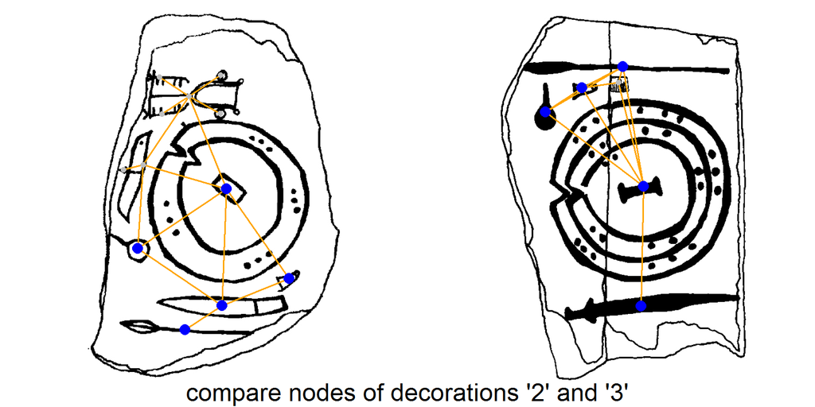

```r
# set wd to data folder
setwd(system.file("extdata", package = "decorr"))
# edges comparisons btw two graphs
g.compar <- list_nds_compar(lgrph,
                            var="type",
                            common.nds.color="blue",
                            different.nds.color="gray")
plot_nds_compar(g.compar,dec.to.compare)
# open image
knitr::include_graphics(out.img)
```

#### Edges

Count the common edges between two decorations

```r
# set wd to data folder
setwd(system.file("extdata", package = "decorr"))
# read imgs, nodes and edges dataframes
imgs <- read.table(system.file("extdata", "imgs.tsv", package = "decorr"),
                   sep="\t",stringsAsFactors = FALSE)
nodes <- read.table(system.file("extdata", "nodes.tsv", package = "decorr"),
                    sep="\t",stringsAsFactors = FALSE)
edges <- read.table(system.file("extdata", "edges.tsv", package = "decorr"),
                    sep="\t",stringsAsFactors = FALSE)
lgrph <- list_dec(imgs,nodes,edges,"type") # call function
df.same_edges <- same_eds(lgrph,"type")
knitr::kable(df.same_edges,row.names = T)
```

|  | 1 | 2 | 3 | 4 |
| --- | --- | --- | --- | --- |
| 1 | 0 | 0 | 1 | 2 |
| 2 | 0 | 0 | 3 | 7 |
| 3 | 1 | 3 | 0 | 1 |
| 4 | 2 | 7 | 1 | 0 |

Here, the decorations `2` and `3` have three (3) common edges. To show them, use the `plot_eds_compar(listg,graph2)` function

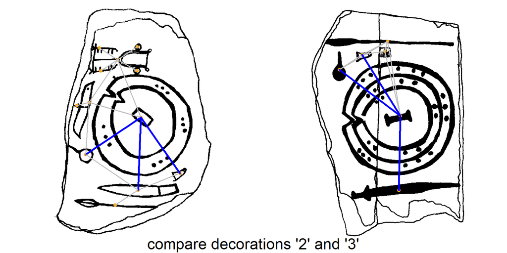

```r
# set wd to data folder
setwd(system.file("extdata", package = "decorr"))
# out.img path is only useful to open the output image
dec.to.compare <- c(2,3)
out.img <- paste0(getwd(),"/compar_eds_",dec.to.compare[1],"_",dec.to.compare[2],".png")
# read data
imgs <- read.table(system.file("extdata", "imgs.tsv", package = "decorr"),
                   sep="\t",stringsAsFactors = FALSE)
nodes <- read.table(system.file("extdata", "nodes.tsv", package = "decorr"),
                    sep="\t",stringsAsFactors = FALSE)
edges <- read.table(system.file("extdata", "edges.tsv", package = "decorr"),
                    sep="\t",stringsAsFactors = FALSE)
lgrph <- list_dec(imgs,nodes,edges,var="type")
g.compar <- list_eds_compar(lgrph,var="type")
plot_eds_compar(g.compar,dec.to.compare)
# open image
knitr::include_graphics(out.img)
```

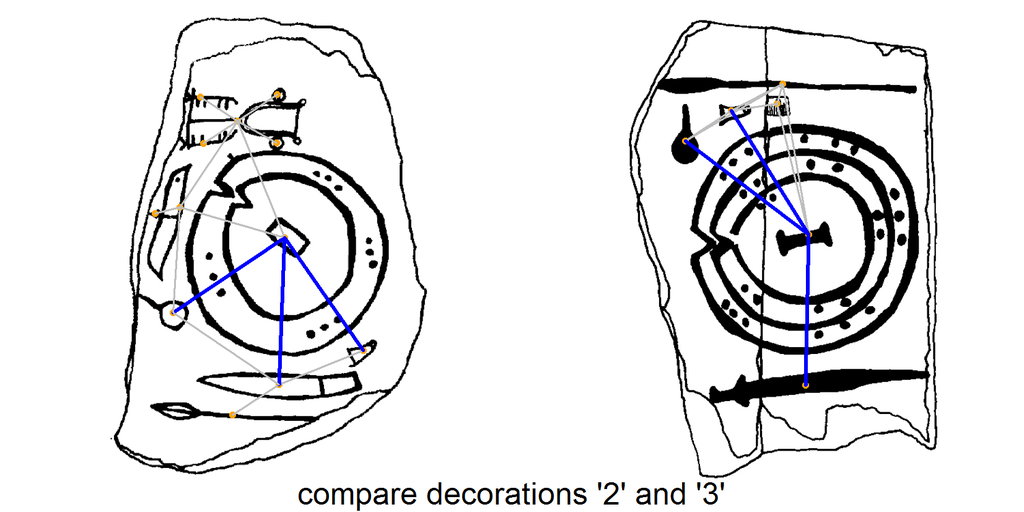

```r
# set wd to data folder
setwd(system.file("extdata", package = "decorr"))
# edges comparisons btw two graphs
g.compar <- list_eds_compar(lgrph,
                            var="type",
                            common.eds.color="blue",
                            different.eds.color="gray")
plot_eds_compar(g.compar,dec.to.compare)
# open image
knitr::include_graphics(out.img)
```

## References

Thomas Huet, thomashuet7[at]gmail.com

- Huet, Thomas. “Geometric graphs to study ceramic decoration” Edited by Mieko Matsumoto and Espen Uleberg. *Exploring Oceans of Data, proceedings of the 44th Conference on Computer Applications and Quantitative Methods in Archaeology, CAA 2016*, Archaeopress, 2018, pp 311-324.